[figure not shown]

# Finding Meaning with KMeans: A Clustering Analysis of Reddit Posts

# Executive Summary

This analysis aims to unravel the topics from a corpus of post titles taken from `reddit.com`. Prior to clustering analysis, the data was cleaned and lemmatized to preserve the context of each word in the corpus. Due to the large size of the data, the dimensions or features were reduced using TruncatedSVD with the optimal number of components set to 3083 based on 90% cumulative variance explained. KMeans was then used as the clustering method in which the optimal k or number of clusters was determined by using internal validation criteria such as the Sum of Squares Distance to Centroids, Calinski-Harabasz Index, Intra-cluster to inter-cluster distance ratio and Silhouette Coefficient. KMeans clustering was performed for both k = 5 and k = 7, and results revealed that increasing the number of k increases balance but reduces parsimoniousness and separation between clusters. In conclusion, five (5) clusters was identified as optimal for this analysis.

# 1. Data Description

The data used in this analysis is a `.txt` file containing authors and post titles from various subreddits taken from `reddit.com`. Data was provided by Professor Erika Legara of the Asian Institute of Management (AIM) Aboitiz School of Innovation and Entrepreneurship (SITE) under the filename `redditdata.txt`.

# 2. Data Processing

### 2.1 Preliminaries: Loading Required Libraries

```python
import pandas as pd
import re
import numpy as np
import matplotlib.pyplot as plt
import nltk
from matplotlib.testing.compare import compare_images
from sklearn.preprocessing import StandardScaler
from sklearn.manifold import TSNE
from sklearn.decomposition import TruncatedSVD
from scipy.spatial.distance import euclidean, cityblock
from IPython.display import HTML
from collections import Counter
from nltk.corpus import stopwords
from sklearn.metrics import calinski_harabaz_score, silhouette_score
from sklearn.feature_extraction.text import TfidfVectorizer
from sklearn.feature_extraction.text import CountVectorizer
from nltk.stem import WordNetLemmatizer
from wordcloud import WordCloud
nltk.download('stopwords')
nltk.download('wordnet')
```

```
True
```

### 2.2 Reading the Data

Let's take a look at the structure of our dataset `redditdata.txt` by loading it to a dataframe.

```python
reddit_df = pd.read_csv('redditdata.txt', sep="\t", usecols=[1,2])
reddit_df_toclean = reddit_df.copy()
reddit_df.head()
```

|  | author | title |
| --- | --- | --- |
| 0 | PrimotechInc | 7 Interesting Hidden Features of apple ios9 |
| 1 | xvagabondx | Need an advice on gaming laptop |
| 2 | nkindustries | Semi automatic ROPP Capping machine / ROPP Cap... |
| 3 | Philo1927 | Microsoft Plumbs Ocean’s Depths to Test Underw... |
| 4 | tuyetnt171 | OPPO F1 chính hãng - Fptshop.com.vn |

`redditdata.txt` contains two (2) columns; author and title respectively. We are interested in clustering the titles of each reddit post but before we subject our data to further analysis, we need to clean it first.

### 2.3.1 Cleaning the Data

For this particular analysis, the criteria set for "clean" data are as follows:

- No punctuations
- Lowercased
- No leading and trailing whitespaces
- Length of each word is greater than two (2)

The first three (3) criteria is standard operating procedure when cleaning text data. For the last criteria, the reasoning for this is that words with less than three (3) letters usually do not give much context and are prone to cleaning errors. By removing these words, we eliminate most of the "noise" in our data and lessen the possible number of tokens after we vectorize the corpus.

```python
# Remove non-word characters and lowercase each title
for i in reddit_df_toclean.columns:
    reddit_df_toclean[i] = reddit_df_toclean[i].str.lower()\
                            .str.replace('[\W\s]+', ' ').str.strip()

reddit_df_toclean.head()
```

|  | author | title |
| --- | --- | --- |
| 0 | primotechinc | 7 interesting hidden features of apple ios9 |
| 1 | xvagabondx | need an advice on gaming laptop |
| 2 | nkindustries | semi automatic ropp capping machine ropp cap s... |
| 3 | philo1927 | microsoft plumbs ocean s depths to test underw... |
| 4 | tuyetnt171 | oppo f1 chính hãng fptshop com vn |

```python
# Getting all the post titles and converting to a list
titles = reddit_df_toclean['title'].tolist()
titles[:5]
```

```
['7 interesting hidden features of apple ios9',
 'need an advice on gaming laptop',
 'semi automatic ropp capping machine ropp cap sealing machine',
 'microsoft plumbs ocean s depths to test underwater data center',
 'oppo f1 chính hãng fptshop com vn']
```

### 2.3.2 Lemmatizing

Next, we'd like to remove the redundancy of words that have the same meaning. Lemmatization is a part of data cleaning which reduces a word in our corpus `titles` to its root word. This way, the meaning of the word is preserved and variations of the root word or lemma are removed. As opposed to stemming, lemmatizing reduces each word to an actual word.

```python
# Lemmatization
wordnet_lemmatizer = WordNetLemmatizer()
titles_lemmatized = []

for title in titles:
    word_list = title.split()
    title_lemmatized = ''
    for word in word_list:
        if len(word) > 2:
            word_lemmatized = wordnet_lemmatizer.lemmatize(word)
            if len(word_lemmatized) > 2:
                title_lemmatized += word_lemmatized + ' '

    titles_lemmatized.append(title_lemmatized.strip())

titles_lemmatized[:5]
```

```
['interesting hidden feature apple ios9',
 'need advice gaming laptop',
 'semi automatic ropp capping machine ropp cap sealing machine',
 'microsoft plumb ocean depth test underwater data center',
 'oppo chính hãng fptshop com']
```

### 2.4 Recap: Raw Data vs Clean Data

To recap, let's take a look at the data before and after cleaning and lemmatization.

```python
reddit_df['title clean'] = titles_lemmatized
reddit_df.head()
```

|  | author | title | title clean |
| --- | --- | --- | --- |
| 0 | PrimotechInc | 7 Interesting Hidden Features of apple ios9 | interesting hidden feature apple ios9 |
| 1 | xvagabondx | Need an advice on gaming laptop | need advice gaming laptop |
| 2 | nkindustries | Semi automatic ROPP Capping machine / ROPP Cap... | semi automatic ropp capping machine ropp cap s... |
| 3 | Philo1927 | Microsoft Plumbs Ocean’s Depths to Test Underw... | microsoft plumb ocean depth test underwater da... |
| 4 | tuyetnt171 | OPPO F1 chính hãng - Fptshop.com.vn | oppo chính hãng fptshop com |

We'll be working with the lemmatized titles from here on.

# 3. Exploratory Data Analysis

With our data cleaned and ready for analysis, let's explore and have a feel of the characteristics of our dataset first. Since we are working with text data, a word frequency plot and word cloud is useful in visualizing the most used words in our corpus.

### 3.1 Word Frequency Plot

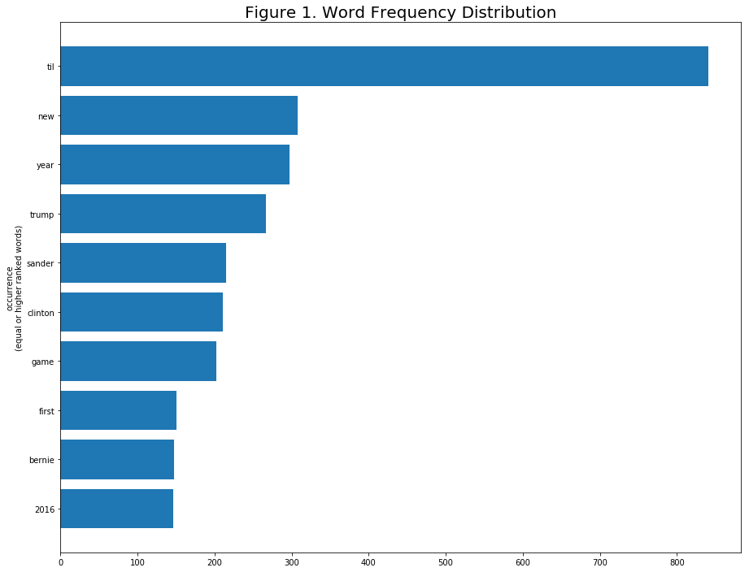

```python
stop_words = list(stopwords.words('english')) # Stop words

no_sw_words = [word for word in ' '.join(titles_lemmatized).split(' ')
               if word not in stop_words] # Removing stop words

wf = dict(Counter(no_sw_words).most_common()) # Word frequency

#Plotting
plt.figure(figsize=(15,12))
plt.barh(list(wf.keys())[:10][::-1], list(wf.values())[:10][::-1])
plt.ylabel('occurrence\n(equal or higher ranked words)');
plt.title('Figure 1. Word Frequency Distribution', fontsize=20);
```

### 3.2 Word Cloud

[figure not shown]

```python
wc = WordCloud(background_color='white', width=2700,
                     height=900, relative_scaling=0.7,max_font_size=500,
                     min_font_size=20, max_words=2000,).\
        generate(' '.join(no_sw_words))

plt.figure(figsize=(15,12))
plt.imshow(wc)
plt.axis('off')
plt.title('Figure 2. Word Cloud Distribution', fontsize=20)
plt.show()
```

Looking at the word frequency plot and word cloud, we can have a sense of what the most used words in our corpus are. We see `til` which means "Today I learned" taking up the top spot. Additionally, we can see names of politicians and words about new year and games. Naturally, we'd expect these words to form our clusters. Clustering will be discussed in the succeeding section.

# 4. Methodology

The general steps for clustering a corpus of text are as follows:

```
1. Vectorize the corpus
2. Reduce the features
3. Visualize the reduced dataset
4. Perform clustering
5. Optimize clusters
```

### 4.1 Vectorizing the Corpus: `TF-IDF Vectorizer`

Since we are dealing with textual data, vectorizing the corpus allows us to transform the data in a manner that computers can understand. For this particular analysis, we will be using the `tf-idf` vectorizer which stands for `Term Frequency-Inverse Data Frequency`.

`Term Frequency` gives us the frequency of the word that appears in each title in our corpus. It is computed as the ratio of the word frequency over the total number of words for each title.

`Inverse Data Frequency` calculates the weight of words that occur in the entire corpus. Rare words have a higher IDF score.

As opposed to other vectorizers such as the `CountVectorizer`, `TF-IDF` is great in distinguishing interesting words in a given title by downscaling words that appear more often across the titles.

```python
tfidf_vectorizer = TfidfVectorizer(token_pattern=r'[a-z]+',
                                   stop_words='english')

#Vectorizing titles_lemmatized
bow_reddit = tfidf_vectorizer.fit_transform(titles_lemmatized)
sample = bow_reddit.todense()

print('Total Number of Tokens:', len(tfidf_vectorizer.vocabulary_))
```

```
Total Number of Tokens: 10659
```

After performing `tf-idf`, the total number of tokens or features of our bag of words representation of the original corpus is 10,659. This size is still large, thus we want to reduce its features to improve processing time.

### 4.2 Feature Reduction: `TruncatedSVD`

For feature reduction, we will be using TruncatedSVD. We want to preserve our original data as much as possible while still reducing the number of features. To do this, we define a function that will choose the optimal number of components based on the desired cumulative variance explained.

```python
# Defining a function to choose the optimal number of components for TSVD
def select_n_components(var_ratio, goal_var: float) -> int:
    '''Returns number of components based on desired cumulative variance
    explained

    Parameters
    ----------
    var_ratio : numpy array
        Array containing explained variance ratios

    goal_var : float
        Desired variance explained
    '''
    total_variance = 0.0
    n_components = 0

    for explained_variance in var_ratio:
        total_variance += explained_variance # Cumulative Variance Explained
        n_components += 1

        if total_variance >= goal_var:
            break

    return n_components
```

Our function requires an input of an array of exlained variance ratio. To get this, we run TruncatedSVD to our original dataset while still keeping the original size of our bag of words.

```python
# Initial run on original bag of words to get the explained variance ratios
tsvd = TruncatedSVD(n_components=bow_reddit.shape[1]-1, random_state=1337)
X_tsvd = tsvd.fit(bow_reddit)
X_tsvd_var_ratios = X_tsvd.explained_variance_ratio_
```

With the explained variance ratios computed, we set our cumulative variance explained to 90% and determine the optimal number of components.

```python
# Identifying optimal number of components
print('Optimal Number of Components for 90% cumulative variance explained:',
      select_n_components(X_tsvd_var_ratios, 0.9))
```

```
Optimal Number of Components for 90% cumulative variance explained: 3083
```

Setting the cumulative variance explained to 90%, we get an optimal number of components amounting to 3083. This means that 90% of the variation in the data is explained by 3083 features.

We then reduce the features of the bag of words representation of our corpus with 3083 components.

```python
#New TSVD with 3083 components
X_TruncatedSVD = TruncatedSVD(n_components=3083, random_state=1337)\
                    .fit_transform(bow_reddit)
```

### 4.3 Visualizing the data: `TSNE`

Let's visualize our reduced dataset using TSNE. This visualization tries to represent the actual clusters of the reduced dataset but does not preserve distances or densities. **Thus, TSNE is only strictly used for visualization!**

```python
#TSNE for visualization
X_reddit_TSNE = TSNE(random_state=1337).fit_transform(
    TruncatedSVD(n_components=3083, random_state=1337)\
    .fit_transform(bow_reddit))
```

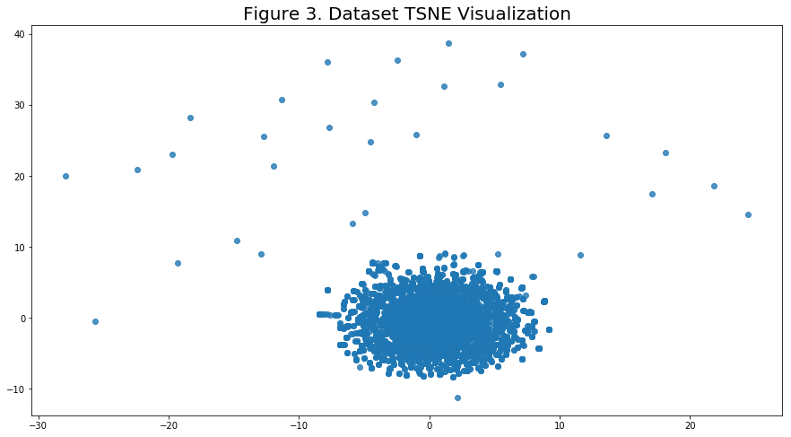

```python
plt.figure(figsize=(15,8))
plt.scatter(X_reddit_TSNE[:,0], X_reddit_TSNE[:,1], alpha=0.8)
plt.title('Figure 3. Dataset TSNE Visualization', fontsize=20);
```

However, the graph is not really telling of what the actual clusters are. So, let's use the KMeans clustering algorithm in an attempt to reveal the actual clusters.

### 4.4 Performing Clustering and Optimization: `KMeans`

Since we are dealing with a dataset that contains 6000 rows and 3083 columns, KMeans is a good clustering algorithm to use as it scales well with large datasets. KMeans works by assigning k number of clusters, represented by their mean and then partitioning each observation so as to assign them to the nearest cluster.

The disadvantage of KMeans however is that determining the optimal number of k can be a bit tricky. We can then determine the optimal number of k by using certain internal validation criteria such as the following:

- **Sum of squares distances to centroids** (SSE): The sum of squares distances to centroids measures the difference in distance of each point from their respective centroid. *Smaller values suggest better clustering.*
- **Calinski-Harabasz index**: The Calinski-Harabasz index is the ratio of the between-clusters dispersion mean and the within-cluster dispersion. *Higher values suggest better clustering.*
- **Intracluster to intercluster distance ratio**: The intracluster to intercluster distance ratio is the ratio of the average distance of pairs $P$ that belong to the same cluster, and the average distance of pairs $Q$ that belong to different clusters. *Smaller values suggest better clustering.*
- **Silhouette coefficient**: Values range from -1 to 1. Large positive values indicate highly separated clustering, and negative values are indicative of some level of “mixing” of data points from different clusters. *Higher values suggest better clustering.*

Since the intracluster to intercluster distance ratio is not a built-in function of sci-kit learn, let's define a function to compute it first.

```python
# Defining Intra to Inter cluster ratio function
def intra_to_inter(X, y, dist, r):
    """Compute intracluster to intercluster distance ratio

    Parameters
    ----------
    X : array
        Design matrix with each row corresponding to a point
    y : array
        Class label of each point
    dist : callable
        Distance between two points. It should accept two arrays, each
        corresponding to the coordinates of each point
    r : integer
        Number of pairs to sample

    Returns
    -------
    ratio : float
        Intracluster to intercluster distance ratio
    """
    P = []
    Q = []

    for i in range(r):
        z = np.random.randint(0, len(X), 2)

        if z[0] == z[1]:
            continue

        elif y[z[0]] == y[z[1]]:
            P.append(dist(X[z[0]], X[z[1]]))

        else:
            Q.append(dist(X[z[0]], X[z[1]]))

    return (np.average(P) / np.average(Q))
```

Additionally, we'd like to take a look at the internal validation criteria values across various k so we can identify the optimal number of clusters, thus we define functions to do so below.

```python
# Creating a cluster range for various k
def cluster_range(X, clusterer, k_start, k_stop):
    """
    Returns a dictionary of the cluster labels and internal validation values

    Parameters
    ----------
    X : design matrix

    clusterer : clustering object

    k_start : int
        Initial k
    k_stop : int
        Final k

    Returns
    -------
    validation : dict
        Contains the cluster labels and internal validation values
    """
    validation = {'ys': [],
                  'inertias': [],
                  'chs': [],
                  'iidrs': [],
                  'scs': []}

    for k in range(k_start, k_stop+1):
        np.random.seed(11)
        kmeans_X = KMeans(
            n_clusters=k, random_state=clusterer.random_state)
        y_predict_X = kmeans_X.fit_predict(X)

        validation['ys'] += [y_predict_X]
        validation['inertias'] += [kmeans_X.inertia_]
        validation['chs'] += [calinski_harabaz_score(X, y_predict_X)]
        validation['iidrs'] += [intra_to_inter(X, y_predict_X,
                                               euclidean, 50)]
        validation['scs'] += [silhouette_score(X,  y_predict_X)]

    return validation
```

```python
# Defining a function to plot each internal validation criteria
def plot_internal(inertias, chs, iidrs, scs):
    """Plot internal validation values"""
    fig, ax = plt.subplots(2,2, figsize=(15,10))
    ks = np.arange(2, len(inertias)+2)

    fig.suptitle('Figure 4. Internal Validation Criteria Values', fontsize=20)

    ax[0,0].plot(ks, inertias, '-o', label='SSE (Lower is better)')
    ax[0,0].axvline(5, ls='--', c='k')
    ax[0,0].axvline(7, ls='--', c='r')
    ax[0,1].plot(ks, chs, '-ro', label='CH (Higher is better)')
    ax[0,1].axvline(5, ls='--', c='k')
    ax[0,1].axvline(7, ls='--', c='r')
    ax[0,0].set_xlabel('$k$')
    ax[0,0].set_title('SSE (Lower is better)')
    ax[0,1].set_xlabel('$k$')
    ax[0,1].set_title('CH (Higher is better)')

    ax[1,0].plot(ks, iidrs, '-go', label='Inter-intra (Lower is better)')
    ax[1,0].axvline(5, ls='--', c='k')
    ax[1,0].axvline(7, ls='--', c='r')
    ax[1,1].plot(ks, scs, '-ko', label='Silhouette coefficient (Higher is better)')
    ax[1,1].axvline(5, ls='--', c='k')
    ax[1,1].axvline(7, ls='--', c='r')
    ax[1,0].set_title('Inter-Intra (Lower is better)')
    ax[1,0].set_xlabel('$k$')
    ax[1,1].set_title('Silhouette (Higher is better)')
    ax[1,1].set_xlabel('$k$')

    return fig
```

#### 4.4.1 Internal Validation Criteria

Solving for the internal validation criteria values for various k gives us the following plot below. By visual inspection, we get the number of clusters that has an "elbow" or the largest difference from the previous value.

```python
res_reddit = cluster_range(X_TruncatedSVD, KMeans(random_state=1337), 2, 11)
```

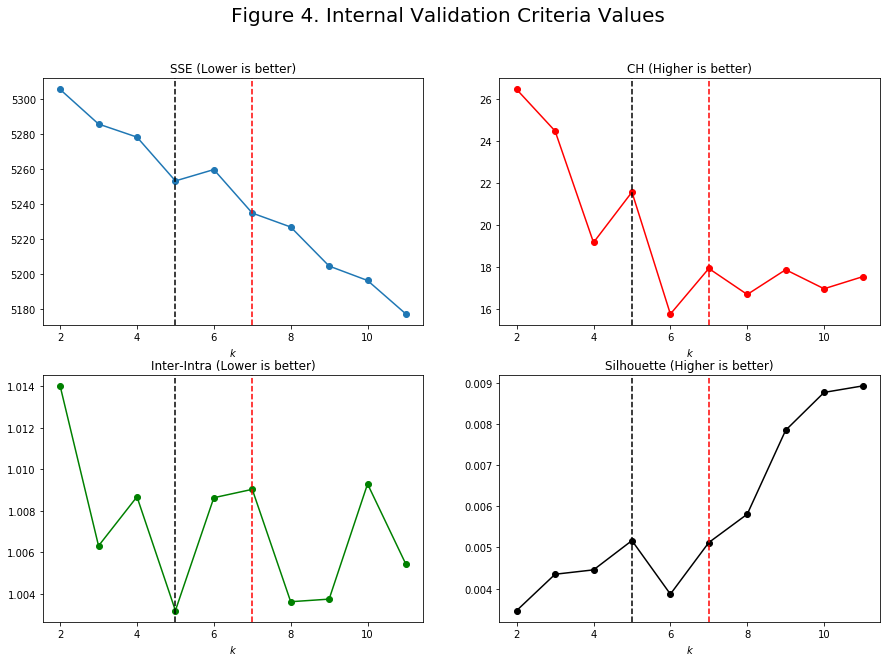

```python
plot_internal(res_reddit['inertias'], res_reddit['chs'], res_reddit['iidrs'],
              res_reddit['scs']);
```

Looking at the internal validation criteria plots, we choose `k = 5 or k = 7`.

# 5. Results: `Revealing Topic Clusters`

After we've defined the optimal k for our KMeans, let's define a function to get the top words of each cluster once we've run KMeans.

```python
# Defining a function to get the n top words of each cluster
def top_words(text, ngram = (1,1), n=None):
    """Returns most frequently occuring words

    Parameters
    ----------
    text : list, series, dataframe
        text data
    ngram : tuple
        ngram range
    n : integer
        number of top words to display

    Returns
    -------
    word_count: list
        list of top words sorted
    """
    vec = CountVectorizer(stop_words='english', lowercase=True,
                          ngram_range = ngram, min_df = 0.0005).fit(text)
    bows = vec.transform(text)
    total_words = bows.sum(axis=0)
    word_count = [(word, total_words[0, idx]) for word, idx in
                  vec.vocabulary_.items()]
    word_count = sorted(word_count, key = lambda x: x[1], reverse=True)
    return word_count[:n]
```

```python
# Define a kmeans clusterer with k, ngrams, and n top words to display as parameters
def kmeans_clusterer_k(k, ngrams=(1,1), n=10):
    '''
    Returns a dataframe containing the n top ngrams of k clusters

    Parameters
    ----------
    k : int
        Number of clusters
    ngrams : tuple
        Minimum and maximum ngrams to use when displaying top words
    n : int
        Number of top words to display

    Returns
    -------
    top_df : pandas DataFrame
        Contains the n top ngrams of k clusters
    '''

    reddit_df['Cluster'] = KMeans(n_clusters=k, random_state = 1337)\
                            .fit(X_TruncatedSVD).labels_

    cluster_list = {}
    for i in range(k):
        cluster_list[i] = reddit_df[reddit_df['Cluster']==i]

    top_df = pd.DataFrame()
    for i in range(k):
        x = pd.Series(top_words(cluster_list[i]['title clean'],
                    ngram = ngrams, n=n), name = 'Cluster_{} \n({}%)'\
                .format(i,round((len(cluster_list[i])*100/len(reddit_df)),2)))
        top_df = top_df.append(x)

    return top_df.T, cluster_list
```

### 5.1 Implementing KMeans with k = 5

```python
top_df511, cluster_list = kmeans_clusterer_k(5, (1,1), n=10)
top_df511
```

|  | Cluster_0 (2.73%) | Cluster_1 (0.95%) | Cluster_2 (88.18%) | Cluster_3 (2.67%) | Cluster_4 (5.47%) |
| --- | --- | --- | --- | --- | --- |
| 0 | (game, 183) | (http, 118) | (til, 820) | (year, 148) | (sander, 203) |
| 1 | (2016, 18) | (review, 42) | (trump, 221) | (new, 137) | (clinton, 183) |
| 2 | (year, 12) | (buycheap, 38) | (new, 141) | (happy, 50) | (bernie, 141) |
| 3 | (video, 12) | (wireless, 10) | (year, 134) | (day, 15) | (hillary, 103) |
| 4 | (2015, 11) | (bluetooth, 9) | (car, 114) | (eve, 14) | (trump, 42) |
| 5 | (like, 11) | (speaker, 9) | (2016, 112) | (owned, 11) | (iowa, 39) |
| 6 | (new, 10) | (player, 9) | (food, 111) | (til, 11) | (campaign, 34) |
| 7 | (just, 8) | (buycheaplow, 7) | (donald, 105) | (resolution, 11) | (email, 31) |
| 8 | (steam, 8) | (mp3, 7) | (state, 105) | (month, 9) | (million, 29) |
| 9 | (best, 7) | (music, 6) | (just, 105) | (000, 9) | (super, 24) |

From the top ten (10) words of each cluster, we have a sense of what these clusters are all about.

- `Cluster_0` : Games / Gaming
- `Cluster_1` : Reviews, Devices, Buying
- `Cluster_2` : TIL, food, etc.
- `Cluster_3` : New Year
- `Cluster_4` : Politics

Let's visualize these clusters by taking a look at their word clouds.

### 5.1.1 Visualizing the five (5) clusters

```python
# Creating word cloud for each cluster
def wordclouder(cluster_number, width=2000, height=1000):
    wc = WordCloud(background_color='white', width=width,
                     height=height, relative_scaling=0.7,max_font_size=500,
                     min_font_size=20, max_words=2000,).\
        generate(cluster_list[cluster_number]['title clean'].str.cat(sep=' '))

    return wc
```

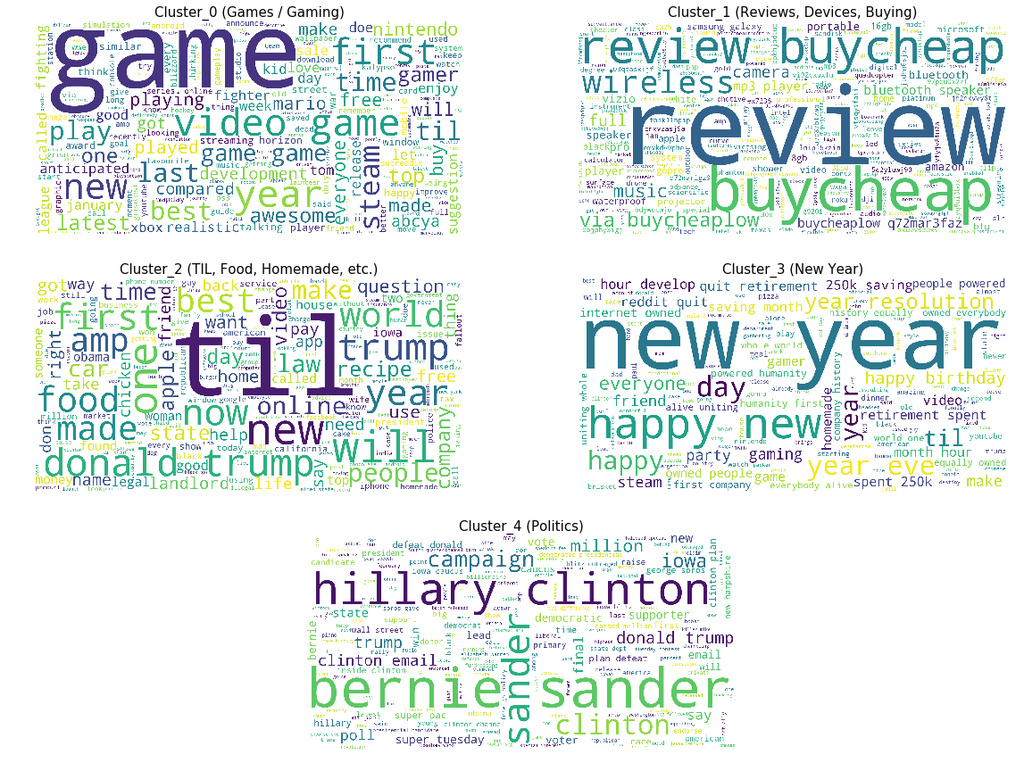

```python
# Plotting word clouds
c0 = wordclouder(0)
c1 = wordclouder(1)
c2 = wordclouder(2)
c3 = wordclouder(3)
c4 = wordclouder(4)

fig = plt.figure(figsize=(20,15))
grid = plt.GridSpec(3,2)

ax1 = plt.subplot(grid[0,0])
ax1.imshow(c0)
ax1.axis('off')
ax1.set_title('Cluster_0 (Games / Gaming)', fontsize=15)

ax2 = plt.subplot(grid[0,1])
ax2.imshow(c1)
ax2.axis('off')
ax2.set_title('Cluster_1 (Reviews, Devices, Buying)', fontsize=15)

ax3 = plt.subplot(grid[1,0])
ax3.imshow(c2)
ax3.axis('off')
ax3.set_title('Cluster_2 (TIL, Food, Homemade, etc.)', fontsize=15)

ax4 = plt.subplot(grid[1,1])
ax4.imshow(c3)
ax4.axis('off')
ax4.set_title('Cluster_3 (New Year)', fontsize=15)

ax5 = plt.subplot(grid[2,:])
ax5.imshow(c4)
ax5.axis('off')
ax5.set_title('Cluster_4 (Politics)', fontsize=15);
```

However, one of the key characteristics of a good cluster is that it should be balanced. So, it's possible that adding more clusters might improve the balance between the clusters. From the optimal k that we've identified earlier, let's explore the effect of increasing the clusters to seven (7).

### 5.2 Implementing KMeans with k = 7

```python
top_df711, cluster_list = kmeans_clusterer_k(7, (1,1), n=10)
top_df711
```

|  | Cluster_0 (2.25%) | Cluster_1 (72.57%) | Cluster_2 (4.27%) | Cluster_3 (1.1%) | Cluster_4 (12.93%) | Cluster_5 (1.2%) | Cluster_6 (5.68%) |
| --- | --- | --- | --- | --- | --- | --- | --- |
| 0 | (people, 75) | (trump, 187) | (new, 212) | (recipe, 71) | (til, 777) | (number, 71) | (sander, 202) |
| 1 | (know, 50) | (game, 152) | (year, 182) | (easy, 5) | (year, 61) | (support, 58) | (clinton, 197) |
| 2 | (til, 45) | (http, 122) | (happy, 45) | (breakfast, 5) | (world, 37) | (phone, 32) | (bernie, 137) |
| 3 | (think, 25) | (2016, 119) | (game, 29) | (cake, 5) | (state, 31) | (877, 32) | (hillary, 106) |
| 4 | (don, 17) | (car, 107) | (york, 17) | (make, 4) | (called, 31) | (technical, 20) | (trump, 41) |
| 5 | (going, 7) | (just, 97) | (day, 16) | (amp, 4) | (time, 29) | (hotmail, 20) | (iowa, 41) |
| 6 | (year, 7) | (food, 94) | (2016, 14) | (chicken, 4) | (trump, 29) | (tech, 16) | (email, 36) |
| 7 | (best, 6) | (donald, 86) | (eve, 14) | (best, 4) | (new, 27) | (788, 15) | (campaign, 34) |
| 8 | (game, 6) | (need, 79) | (resolution, 12) | (egg, 4) | (war, 26) | (9452, 15) | (million, 30) |
| 9 | (business, 6) | (best, 74) | (2015, 11) | (healthy, 3) | (woman, 26) | (kindle, 14) | (super, 24) |